# Basic statistics for health research - week 1, ex. 1

### -1. Setup (cont’d) - helper functions

Define helper functions (if you do the same or almost the same thing more than twice, you should create a function for that specific task.) `tribble` is a way to create dataframes row-wise; `pivot_longer` and `pivot_wider` come from the `tidyr` package and allows for converting between long and wide format (more on this later in the course).

```r
summary_stats <- function(x) {
    "
    x: vector of continuous values
    "
    tribble(
        ~ statistic, ~ value,
        "mean", mean(x, na.rm = TRUE),
        "std_dev", sd(x, na.rm = TRUE),
        "median", median(x, na.rm = TRUE),
        "p25", quantile(x, probs = 0.25, na.rm = TRUE),
        "p75", quantile(x, probs = 0.75, na.rm = TRUE),
        "min", min(x, na.rm = TRUE),
        "max", max(x, na.rm = TRUE),
        "n_missing", sum(is.na(x))
    )
}

pivot_around_sex <- function(df) {
    "
    df is a data frame with at least a column named sex and some data columns to pivot
    "
    df %>%
        pivot_longer(cols = -sex, names_to = "statistic", values_to = "value") %>%
        pivot_wider(names_from = "sex")
}
```

### 1. Data wrangling

Remember that `transmute` discards all columns not modified or referenced (“mentioned”) in the call. It’s an easy to do wrangling + renaming of incoming data while throwing away the old columns. I prefer to keep all data wrangling together, but you find out as you go what you need: it’s an iterative process, and so it makes sense to come back and add the data wrangling here when you realise you need something (e.g. BMI in this example).

```r
df <- read_delim("http://staff.pubhealth.ku.dk/~sr/BasicStatistics/datasets/sundby.txt", delim = " ", na = ".") %>%
    transmute(weight = v75,
              height = v76 / 100, # cm ~> metres
              sex = factor(kon, levels = c(1, 2), labels = c("male", "female")),
              bmi = weight / height^2)
glimpse(df) # gives a nice overview of the actual values in the dataframe ≠ summary()
```

```
## Rows: 1,474
## Columns: 4
## $ weight <dbl> 75, 58, NA, 85, 80, 79, 90, 55, 72, 62, 63, 81, 76, 60, 85, 70…
## $ height <dbl> 1.70, 1.75, 1.91, 1.79, 1.80, 1.86, 1.90, 1.76, 1.74, 1.68, 1.…
## $ sex    <fct> male, male, male, male, male, male, male, male, male, male, ma…
## $ bmi    <dbl> 25.95156, 18.93878, NA, 26.52851, 24.69136, 22.83501, 24.93075…
```

Get a few summary stats; we have 1474 observations with 4 variables.

```r
summary(df)
```

```
##      weight           height          sex           bmi
##  Min.   : 32.00   Min.   :1.480   male  :647   Min.   :11.63
##  1st Qu.: 60.00   1st Qu.:1.660   female:827   1st Qu.:21.26
##  Median : 70.00   Median :1.720                Median :23.11
##  Mean   : 70.91   Mean   :1.729                Mean   :23.63
##  3rd Qu.: 80.00   3rd Qu.:1.800                3rd Qu.:25.38
##  Max.   :140.00   Max.   :2.000                Max.   :39.64
##  NA's   :29       NA's   :37                   NA's   :58
```

#### Pattern in missingness

The rows are missingness pattern (0 = variable is missing). The left-most column is the number of patients with the respective missingness patters, the right-most column the number of variables missing in each pattern, the bottom-most row the number of participants with missing values for the respective variables.

```r
md.pattern(df, plot = FALSE)
```

```
##      sex weight height bmi
## 1416   1      1      1   1   0
## 29     1      1      0   0   2
## 21     1      0      1   0   2
## 8      1      0      0   0   3
##        0     29     37  58 124
```

### 2. Weights of men and women

The weight distributions seem to differ although they do overlap quite a lot.

#### Numerical summary

```r
df %>%
    group_by(sex) %>%
    summarise(summary_stats(weight)) %>% # note that summarise() here actually reduces to >1 row
    arrange(statistic, sex)
```

```
## # A tibble: 16 x 3
##    sex    statistic value
##    <fct>  <chr>     <dbl>
##  1 male   max       140
##  2 female max       117
##  3 male   mean       78.5
##  4 female mean       64.9
##  5 male   median     77
##  6 female median     63
##  7 male   min        34
##  8 female min        32
##  9 male   n_missing   8
## 10 female n_missing  21
## 11 male   p25        71
## 12 female p25        57
## 13 male   p75        85
## 14 female p75        70
## 15 male   std_dev    11.9
## 16 female std_dev    11.4
```

#### Plotting

QQ-plot

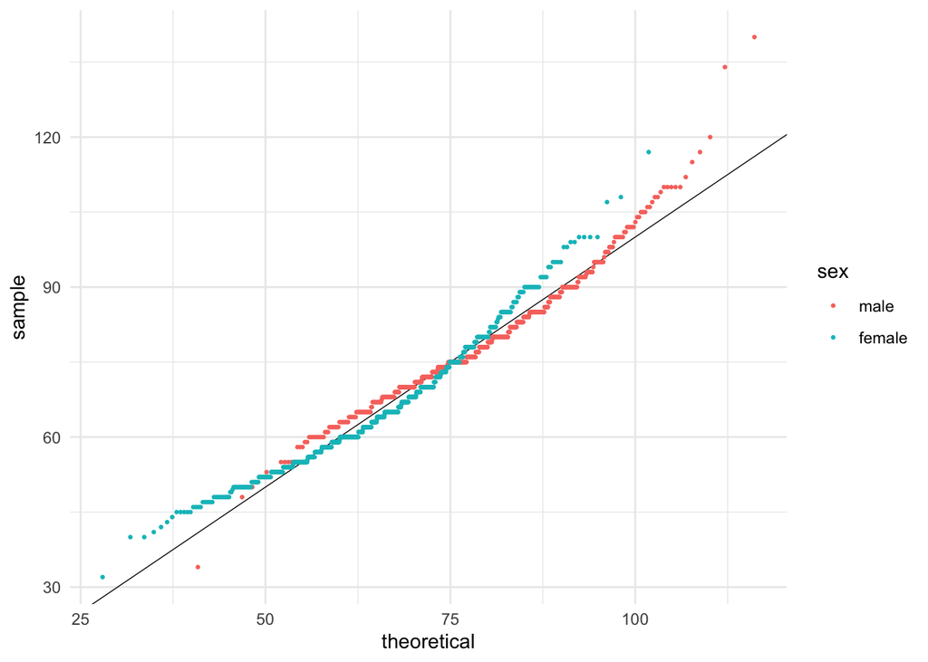

```r
ggplot(df, aes(sample = weight, colour = sex)) +
    geom_abline(intercept = 0, slope = 1, size = 0.25) + # the name comes from the equation: y = ax + b
    stat_qq_point(size = 0.5) # from qqplotr
```

First a histogram of the weight distribution overall. Note: different values of `binwidth` will change the appearance quite a lot (as all histograms)

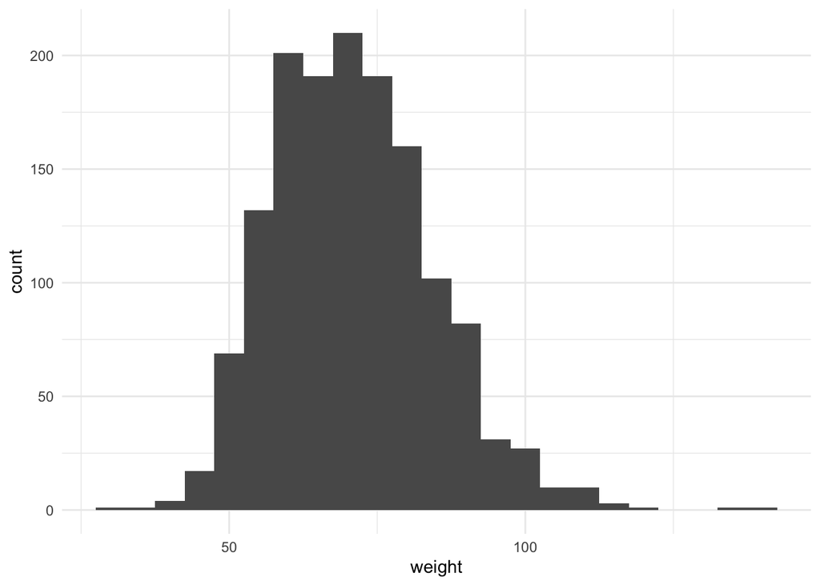

```r
ggplot(df, aes(x = weight)) +
    geom_histogram(binwidth = 5)
```

We often want to show men and women separately. The “naive” approach seems weird because `ggplot2` stacks histograms by default.

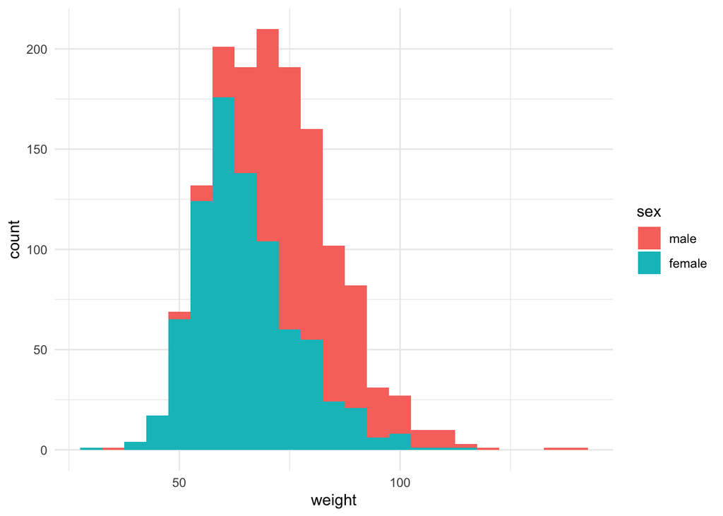

```r
ggplot(df, aes(x = weight)) +
    geom_histogram(aes(fill = sex), binwidth = 5)
```

So we tell `ggplot2` to dodge (= “unstack”) the bars

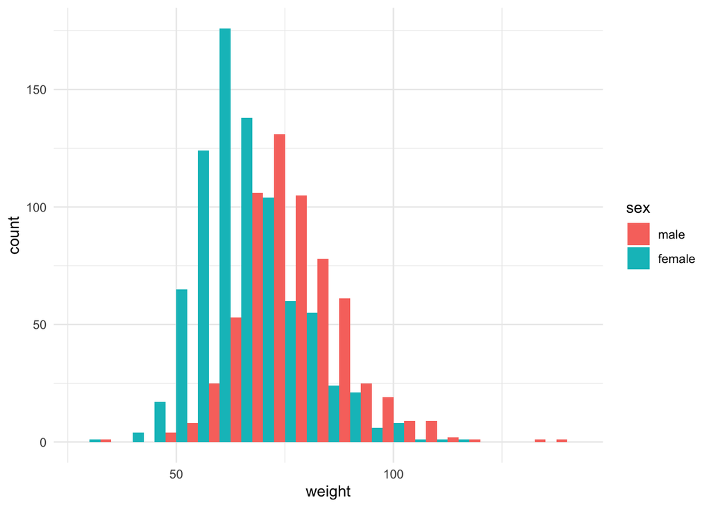

```r
ggplot(df, aes(x = weight)) +
    geom_histogram(aes(fill = sex), binwidth = 5, position = "dodge")
```

```r
table(df$sex) # many more females, so a crude histogram might be misleading
```

```
##
##   male female
##    647    827
```

–so we want “normalised” histograms instead. `ggplot2` computed some values (which ones depends on the `geom`), and these can be called surrounding them by two periods (see e.g. `?geom_histogram`)

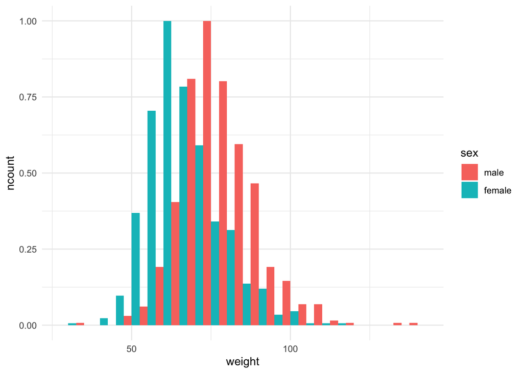

```r
ggplot(df, aes(x = weight)) +
    geom_histogram(aes(fill = sex, y = ..ncount..), binwidth = 5, position = "dodge")
```

I think multiple histrograms together are ugly and prefer to plot the frequencies as lines instead (= frequency polygons in `ggplot2`; weird name, pretty plot). I add some plot cosmetics to have a nice-looking and near publication-ready plot:

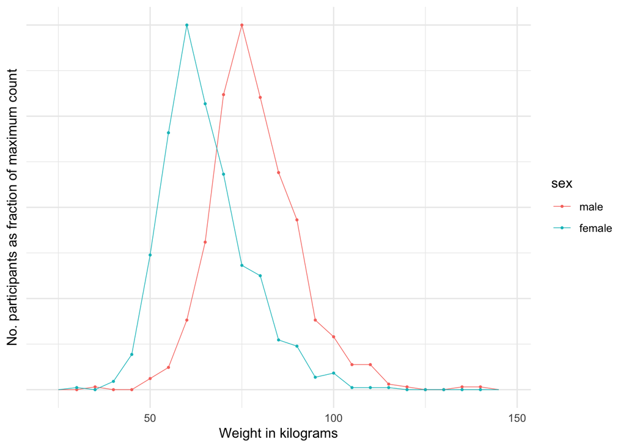

```r
ggplot(df, aes(x = weight, colour = sex, y = ..ncount..)) +
    geom_freqpoly(binwidth = 5, size = 0.25) +
    stat_bin(size = 0.5, binwidth = 5, geom = "point", position = "identity") +
    labs(x = "Weight in kilograms", y = "No. participants as fraction of maximum count") +
    theme(axis.text.y = element_blank())
```

#### Alternatives

Violin plots are richer than boxplots and can unearth patterns in the distribution that escape boxplots. Their appearance depends heavily on their settings so be careful.

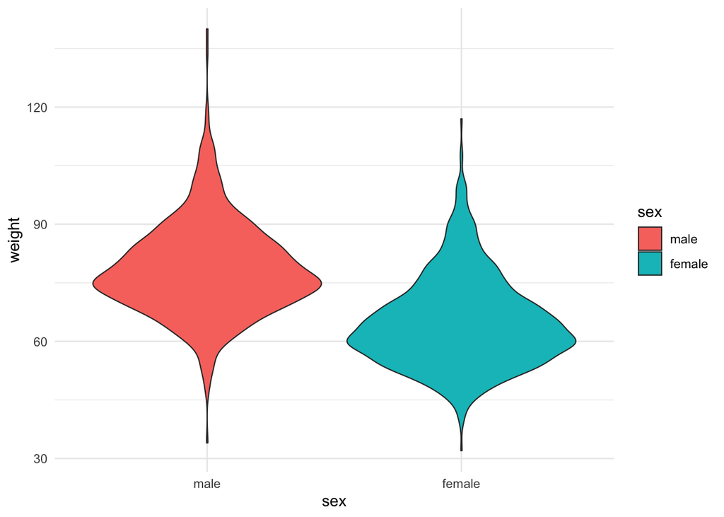

```r
ggplot(df, aes(x = sex, y = weight, fill = sex)) +
    geom_violin(size = 0.4)
```

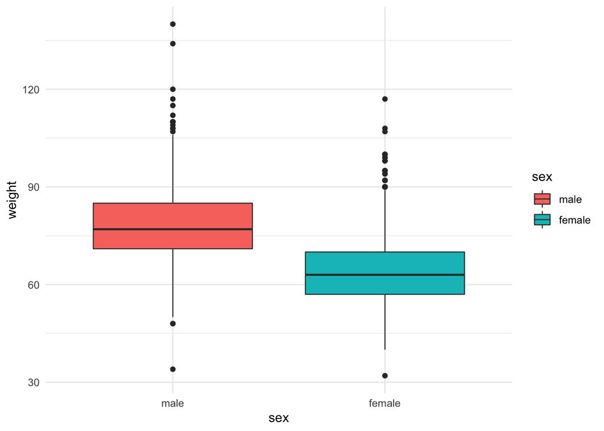

```r
ggplot(df, aes(x = sex, y = weight, fill = sex)) +
    geom_boxplot(size = 0.4)
```

### 3. Construct reference intervals

#### On the “cirka 2” factor

Often, you can just use 2 or 1.96 (because the $t$ distribution gets closer to the Normal as N becomes large). This is just to show the relationship between the “circa 2”-factor and the number of observations. `tibble`s are a modern version of dataframes (they arrived with `dplyr`) and offer three nice features: columns are created “on-the-fly” so you can use values from previous columns to create a new one (this is not possible with `data.frame()`), they print in a nice way (unlike dataframes; this becomes more important for larger dataframes/tibbles), they don’t convert strings to factors automatically (the `read_*()` functions from `readr` have the same feature unlike the `read.*()` in base R). As we can see, already for around 100 observations, the 1.96 approximation is quite good.

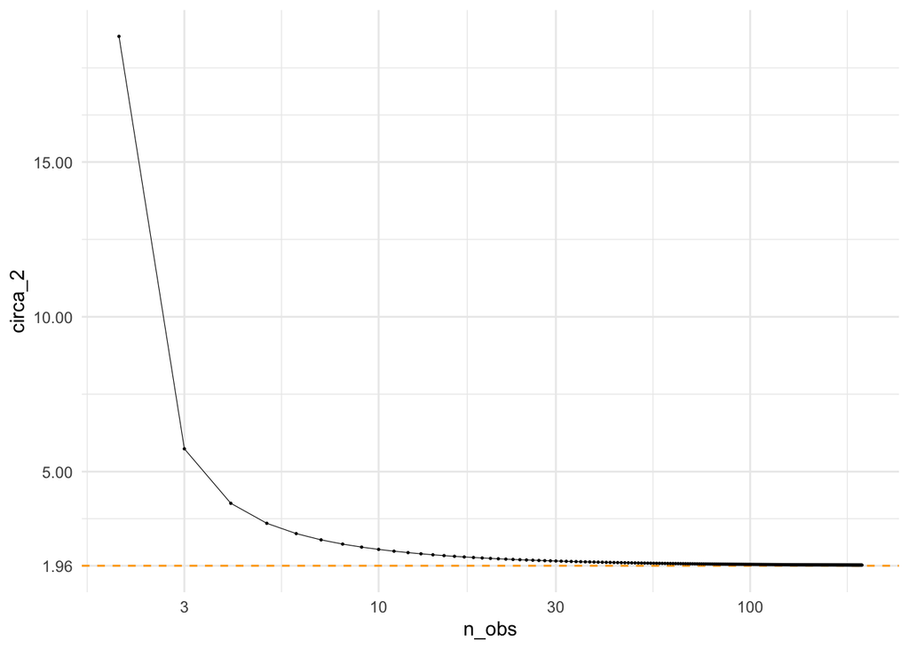

```r
tibble(n_obs = 2:200, # n_obs = 1 is meaningless as a single observation can't have a distribution
       circa_2 = (1 + 1/n_obs) * qt(0.975, n_obs - 1)) %>%
    ggplot(aes(x = n_obs, y = circa_2)) +
        geom_hline(yintercept = qt(0.975, Inf), colour = "orange", linetype = 2, size = 0.5) +
        geom_line(size = 0.2) +
        geom_point(size = 0.2) +
        scale_x_log10() +
        scale_y_continuous(breaks = c(round(qt(0.975, Inf), 2), 5, 10, 15, 20))
```

### Using the Normality assumption

```r
df %>%
    filter(!is.na(weight)) %>% # keep the rows where weight is *not* missing
    group_by(sex) %>%
    summarise(mean = mean(weight),
              std_dev = sd(weight),
              interval_factor = sqrt(1 + 1/n()) * qt(0.975, n() - 1),
              ci_lo_norm = mean - interval_factor * std_dev,
              ci_hi_norm = mean + interval_factor * std_dev,
              ci_lo_nonnorm = quantile(weight, 0.025),
              ci_hi_nonnorm = quantile(weight, 0.975)) %>%
    pivot_around_sex() # this is just cosmetics so the results fit better
```

```
## # A tibble: 7 x 3
##   statistic         male female
##   <chr>            <dbl>  <dbl>
## 1 mean             78.5   64.9
## 2 std_dev          11.9   11.4
## 3 interval_factor   1.97   1.96
## 4 ci_lo_norm       55.1   42.4
## 5 ci_hi_norm      102.    87.4
## 6 ci_lo_nonnorm    59.0   47
## 7 ci_hi_nonnorm   106     91.8
```

### 5. Scatterplot of weight ~ height

The simple scatterplot looks nice but is actually deceiving.

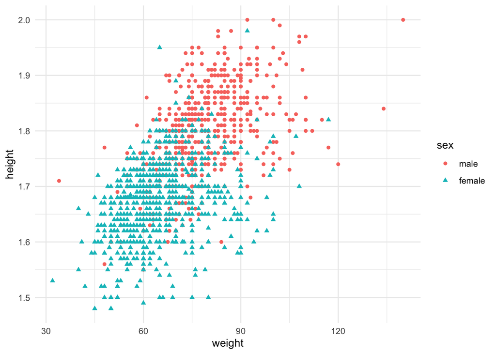

```r
ggplot(df, aes(x = weight, y = height, shape = sex, colour = sex)) +
    geom_point()
```

If we make the points transparent, we see many points are plotted on top of each other (over-plotting) which means the first opaque scatterplot is “hiding” observations. Making points semi-transparent helps (`alpha = 1` is fully opaque, `alph = 0` is fully transparent):

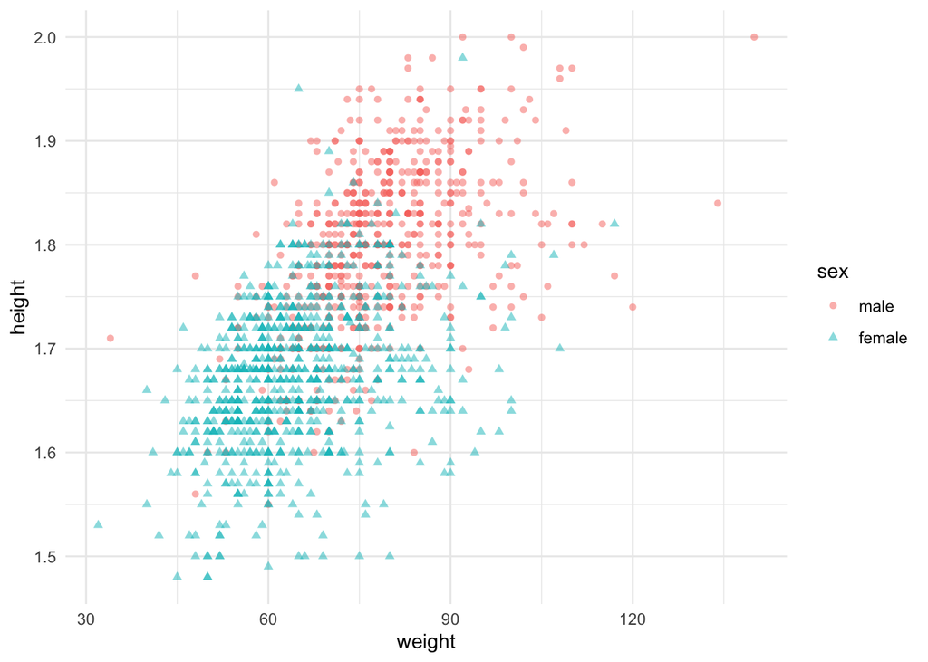

```r
ggplot(df, aes(x = weight, y = height, shape = sex, colour = sex)) +
    geom_point(alpha = 0.5)
```

But we can also try a heatmap-plot (note again the use of a computed value surrouned by two periods, here `..ncount..`)

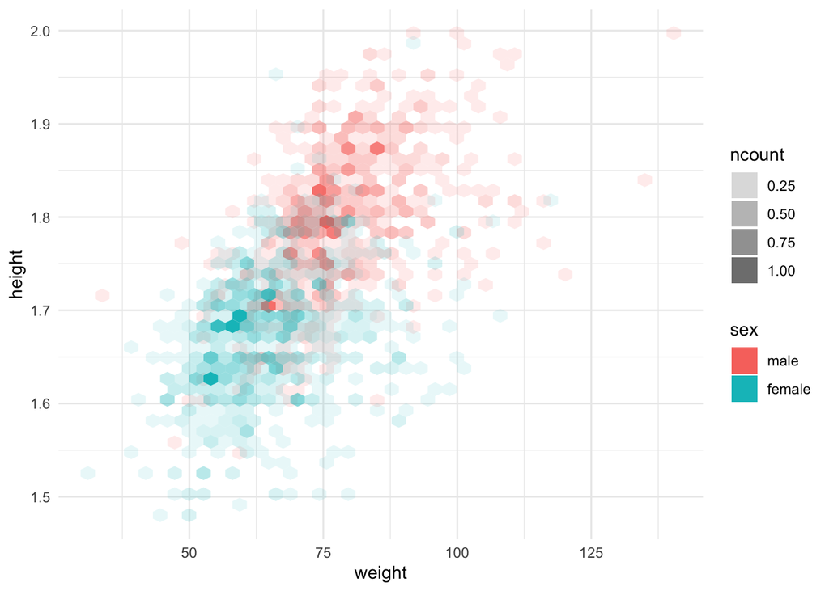

```r
ggplot(df, aes(x = weight, y = height)) +
    geom_hex(aes(alpha = ..ncount.., fill = sex), bins = 40)
```

A contour plot is perhaps less confusing than the heatmap plot because overlaying of colours isn’t handled well.

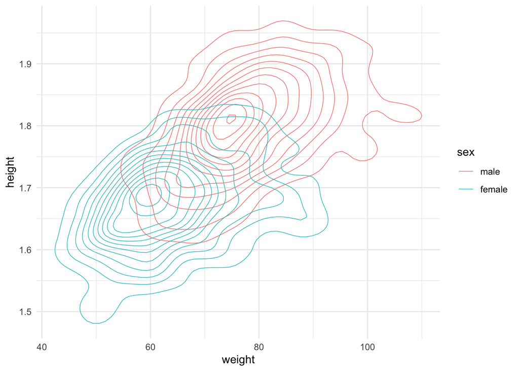

```r
ggplot(df, aes(x = weight, y = height, colour = sex)) +
    geom_density_2d(size = 0.25)
```

### 6. BMI

The distribution seems about right: right-skewed, with some extreme values but mostly in the normal range. BMI doesn’t seem to have a Normal distribution, however. I’m overlaying the plot with the density of the Normal distribution that we assume based on the mean and standard deviation (blue curve). If this is too difficult, just dont’ try to understand the `stat_function` line and we’ll come back to it later in the course.

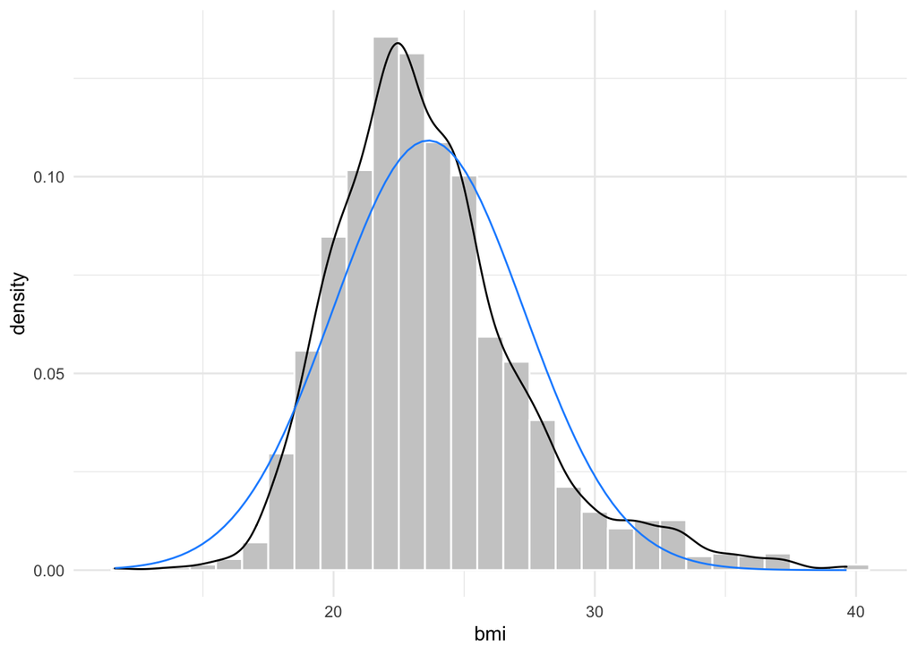

```r
df_bmi <- df %>%
    filter(!is.na(bmi))

ggplot(df_bmi, aes(x = bmi)) +
    geom_histogram(aes(y = ..density..), colour = "white", fill = "grey80", binwidth = 1) +
    geom_density() +
    stat_function(colour = "dodgerblue", fun = dnorm, args = list(mean = mean(df_bmi$bmi), sd = sd(df_bmi$bmi)))
```

The QQ-plot is also off

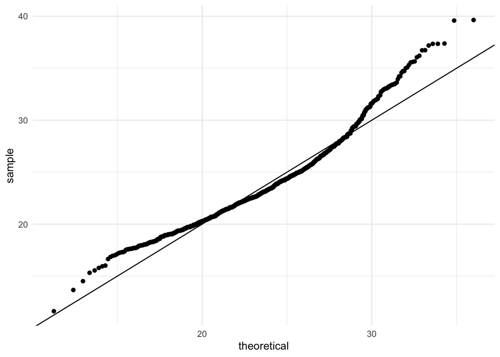

```r
ggplot(df_bmi, aes(sample = bmi)) +
    geom_abline(intercept = 0, slope = 1) +
    stat_qq_point()
```

However, it might be misleading to plot men and women together:

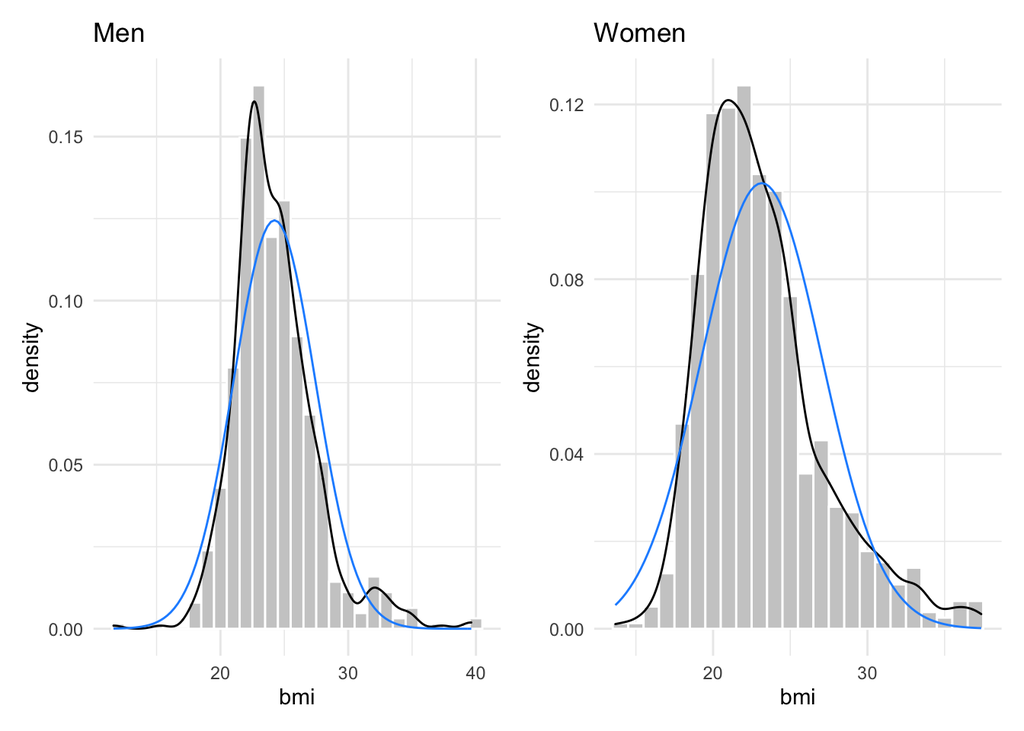

```r
df_men <- df_bmi %>%
    filter(sex == "male")
df_women <- df_bmi %>%
    filter(sex == "female")

p_men <- ggplot(df_men, aes(x = bmi)) +
    geom_histogram(aes(y = ..density..), colour = "white", fill = "grey80", binwidth = 1) +
    geom_density() +
    stat_function(colour = "dodgerblue", fun = dnorm, args = list(mean = mean(df_men$bmi), sd = sd(df_men$bmi))) +
    labs(title = "Men")

p_women <- ggplot(df_women, aes(x = bmi)) +
    geom_histogram(aes(y = ..density..), colour = "white", fill = "grey80", binwidth = 1) +
    geom_density() +
    stat_function(colour = "dodgerblue", fun = dnorm, args = list(mean = mean(df_women$bmi), sd = sd(df_women$bmi))) +
    labs(title = "Women")

p_men + p_women # the patchwork package allows us to patch together plots like this
```

Or as the frequency polygon instead:

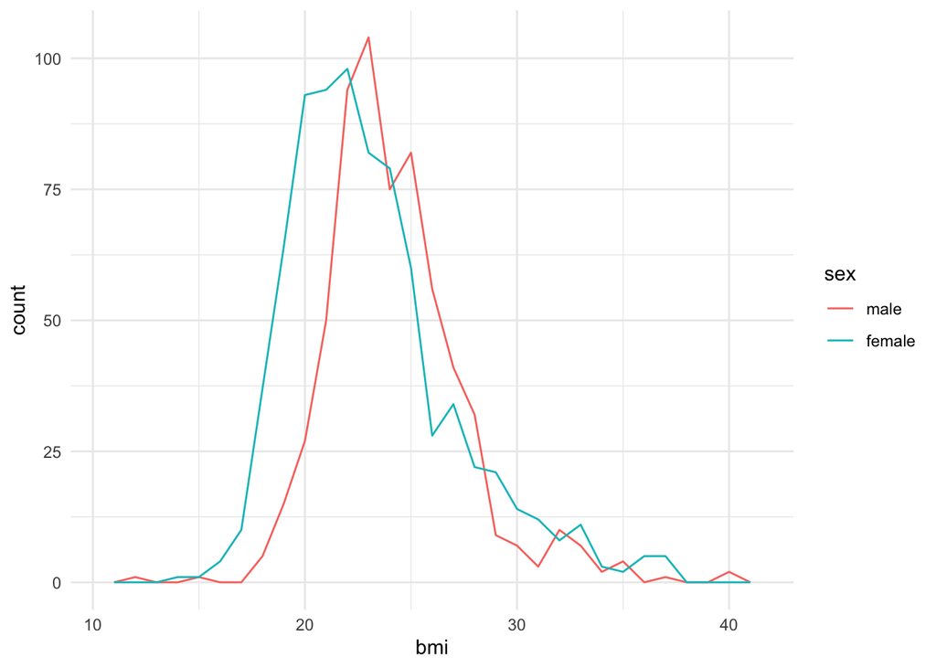

```r
ggplot(df_bmi, aes(x = bmi, colour = sex)) +
    geom_freqpoly(binwidth = 1)
```

### Determine normal ranges for each sex with and without normality assumption

Note that use of `sum` and `mean` of TRUE/FALSE vectors (whether BMI is between the lower and higer bounds of the reference intervals.)

```r
df_bmi %>%
    group_by(sex) %>%
    summarise(mean = mean(bmi),
              std_dev = sd(bmi),
              interval_factor = sqrt(1 + 1/n()) * qt(0.975, n() - 1), # = circa 2
              ci_lo_norm = mean - interval_factor * std_dev,
              ci_hi_norm = mean + interval_factor * std_dev,
              n_outside_ci_norm = sum(!between(bmi, ci_lo_norm, ci_hi_norm)),
              prop_outside_ci_norm = mean(!between(bmi, ci_lo_norm, ci_hi_norm)),
              ci_lo_nonnorm = quantile(bmi, 0.025),
              ci_hi_nonnorm = quantile(bmi, 0.975),
              n_outside_ci_nonnorm = sum(!between(bmi, ci_lo_nonnorm, ci_hi_nonnorm)),
              prop_outside_ci_nonnorm = mean(!between(bmi, ci_lo_nonnorm, ci_hi_nonnorm))) %>%
    pivot_around_sex() # again, just cosmetics
```

```
## # A tibble: 11 x 3
##    statistic                  male  female
##    <chr>                     <dbl>   <dbl>
##  1 mean                    24.2    23.2
##  2 std_dev                  3.20    3.91
##  3 interval_factor          1.97    1.96
##  4 ci_lo_norm              17.9    15.5
##  5 ci_hi_norm              30.5    30.8
##  6 n_outside_ci_norm       34      45
##  7 prop_outside_ci_norm     0.0541  0.0571
##  8 ci_lo_nonnorm           19.0    17.6
##  9 ci_hi_nonnorm           32.5    33.2
## 10 n_outside_ci_nonnorm    32      40
## 11 prop_outside_ci_nonnorm  0.0510  0.0508
```

### 7. Using log-BMI

Better agreement between intervals based on normality assumption and empirical estimates.

```r
df_bmi %>%
    mutate(log_bmi = log(bmi)) %>%
    group_by(sex) %>%
    summarise(mean = mean(log_bmi),
              std_dev = sd(log_bmi),
              interval_factor = sqrt(1 + 1/n()) * qt(0.975, n() - 1),
              ci_lo_norm = exp(mean - interval_factor * std_dev),
              ci_hi_norm = exp(mean + interval_factor * std_dev),
              n_outside_ci_norm = sum(!between(bmi, ci_lo_norm, ci_hi_norm)),
              prop_outside_ci_norm = mean(!between(bmi, ci_lo_norm, ci_hi_norm)),
              ci_lo_nonnorm = exp(quantile(log_bmi, 0.025)),
              ci_hi_nonnorm = exp(quantile(log_bmi, 0.975)),
              n_outside_ci_nonnorm = sum(!between(bmi, ci_lo_nonnorm, ci_hi_nonnorm)),
              prop_outside_ci_nonnorm = mean(!between(bmi, ci_lo_nonnorm, ci_hi_nonnorm))) %>%
    pivot_around_sex()
```

```
## # A tibble: 11 x 3
##    statistic                  male  female
##    <chr>                     <dbl>   <dbl>
##  1 mean                     3.18    3.13
##  2 std_dev                  0.128   0.161
##  3 interval_factor          1.97    1.96
##  4 ci_lo_norm              18.7    16.7
##  5 ci_hi_norm              30.9    31.3
##  6 n_outside_ci_norm       39      41
##  7 prop_outside_ci_norm     0.0621  0.0520
##  8 ci_lo_nonnorm           19.0    17.6
##  9 ci_hi_nonnorm           32.5    33.2
## 10 n_outside_ci_nonnorm    32      40
## 11 prop_outside_ci_nonnorm  0.0510  0.0508
```